# EVS Data Analysis by Country

Kangrui Liu

2025-03-25

# Introduction

This report explores the 2017 European Values Study (EVS) for AT, focusing on two variables measuring attitudes toward gender roles (v72) and immigration (v80). The analysis includes descriptive statistics, visualization of how these attitudes change with age, and regression modeling incorporating age, age squared, sex, and education.

# Data Preparation

```r
load("data/evs_clean.RData")

evs_country <- evs_clean %>%
  filter(country == params$country)
```

# Descriptive Statistics

## Continuous Variables

```r
evs_country %>%
  dplyr::select(age, v72, v80) %>%
  summary()
```

```
##       age            v72             v80
##  Min.   :12.0   Min.   :1.000   Min.   :1.000
##  1st Qu.:15.0   1st Qu.:2.000   1st Qu.:2.000
##  Median :18.0   Median :2.000   Median :2.000
##  Mean   :19.4   Mean   :2.531   Mean   :2.591
##  3rd Qu.:20.0   3rd Qu.:3.000   3rd Qu.:4.000
##  Max.   :70.0   Max.   :4.000   Max.   :5.000
```

## Categorical Variables

```r
evs_country %>%
  count(sex) %>%
  kable(caption = "Frequency Table for Sex")
```

Frequency Table for Sex

| sex | n |
| --- | --- |
| 1 | 691 |
| 2 | 848 |

```r
evs_country %>%
  count(education) %>%
  kable(caption = "Frequency Table for Education")
```

Frequency Table for Education

| education | n |
| --- | --- |
| 1 | 210 |
| 2 | 1066 |
| 3 | 257 |
| 66 | 6 |

# Visualizations

## v72 by Age

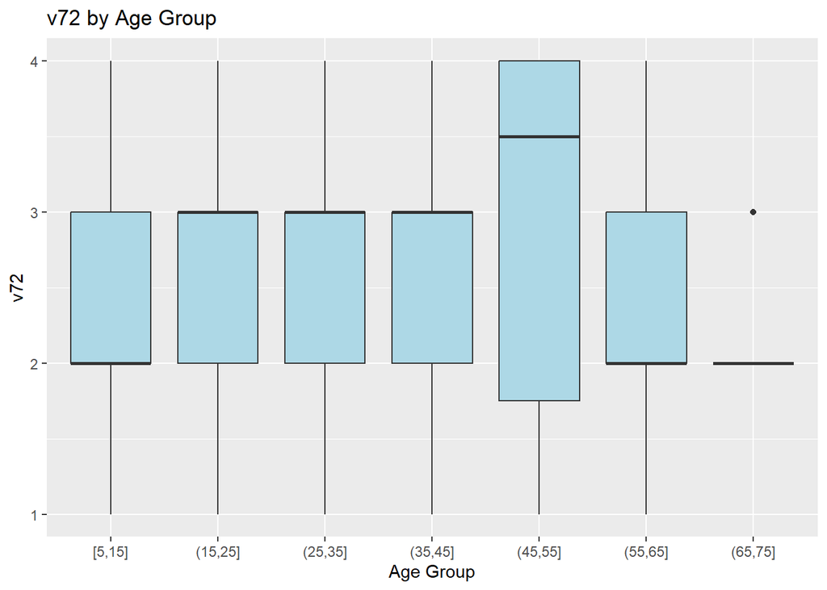

```r
ggplot(evs_country, aes(x = cut_width(age, width=10), y = v72)) +
  geom_boxplot(fill = "lightblue") +
  labs(title = "v72 by Age Group", x = "Age Group", y = "v72")
```

> **Interpretation (v72):** The boxplot illustrates how attitudes towards gender roles (`v72`) vary across different age groups in AT. Middle-aged groups generally show slightly higher median scores, indicating potentially different attitudes compared to younger and older age groups in this country.

## v80 by Age

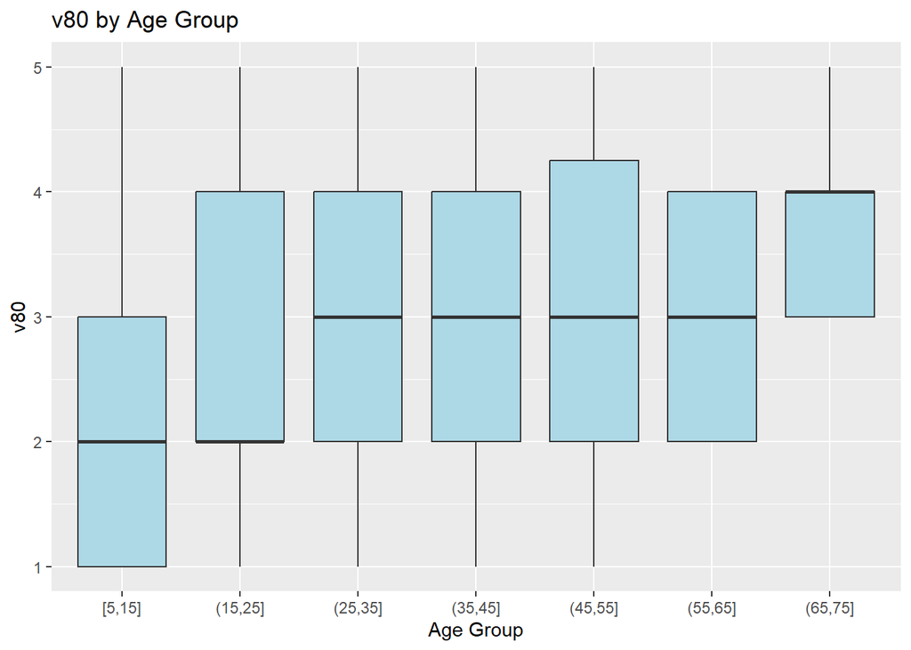

```r
ggplot(evs_country, aes(x = cut_width(age, width=10), y = v80)) +
  geom_boxplot(fill = "lightblue") +
  labs(title = "v80 by Age Group", x = "Age Group", y = "v80")
```

# Regression Analysis

```r
mod1 <- lm(v72 ~ age + age_sq + sex + education, data = evs_country)
mod2 <- lm(v80 ~ age + age_sq + sex + education, data = evs_country)

screenreg(list("v72" = mod1, "v80" = mod2))
```

```
##
## =====================================
##              v72          v80
## -------------------------------------
## (Intercept)     1.31 ***     0.85 **
##                (0.18)       (0.27)
## age             0.07 ***     0.11 ***
##                (0.01)       (0.02)
## age_sq         -0.00 ***    -0.00 ***
##                (0.00)       (0.00)
## sex             0.13 **      0.10
##                (0.05)       (0.07)
## education      -0.01        -0.01
##                (0.01)       (0.01)
## -------------------------------------
## R^2             0.03         0.04
## Adj. R^2        0.03         0.04
## Num. obs.    1539         1539
## =====================================
## *** p < 0.001; ** p < 0.01; * p < 0.05
```

# Dynamic Interpretation

In AT, the regression results show that sex has a positive relationship with attitudes towards gender roles (v72) (Coefficient = 0.13; p-value = 0.003). For attitudes towards immigration (v80), sex shows a positive relationship (Coefficient = 0.1; p-value = 0.127).

# Summary

This report provides a detailed overview of attitudes towards gender roles and immigration in AT, highlighting key demographic insights, visualizing how these attitudes vary by age, and exploring their statistical relationships with demographic predictors.